# Number of times in Vigorous Physical Activity

# 1 Description of DataSchema variable

The description of harmonised variable is the following:

- Short name: `n_vig_pa`
- Variable label: `Number of times during past 2 weeks engaging in vigorous exercise`
- Variable description: `Number of times during past 2 weeks engaging in vigorous exercise`
- Domain: `Lifestyle and health behaviours`
- Value type: `continuous`
- Category missings:

| **Code** | **Category Label** |
| --- | --- |
| 991 | CAPI/interviewer error |
| 992 | Impute |
| 993 | Disable to measure |
| 994 | Not attempt/not done |
| 995 | Does not answer |
| 996 | Not applicable |
| 997 | Refuse |
| 998 | Do not know |
| 999 | Missing |

# 2 Data process

## 2.1 England

### 2.1.1 Wave 1

#### 2.1.1.1 Study-specific variable description

| **Name** | `r1vgactx_e` |
| --- | --- |
| **Label** | `Frequency vigorous physical activities` |
| **Table name** | `h_elsa` |
| **Categories** | `2 = Respondent reported taking part in the given level of physical activity more than once a week` `3 = 1 per week` `4 = 1-3 per month` `5 = hardly ever or never` |
| **Missings** | `NA` |
| **Description** |  |

r1vgactx_e

| Sample size | Missing values |
| --- | --- |
| 12099 | 194 |

Category

|  | 2 | 3 | 4 | 5 |
| --- | --- | --- | --- | --- |
| Frequency | 2145.00 | 1157.00 | 1122.00 | 7481.00 |
| Percentage | 17.73 | 9.56 | 9.27 | 61.83 |

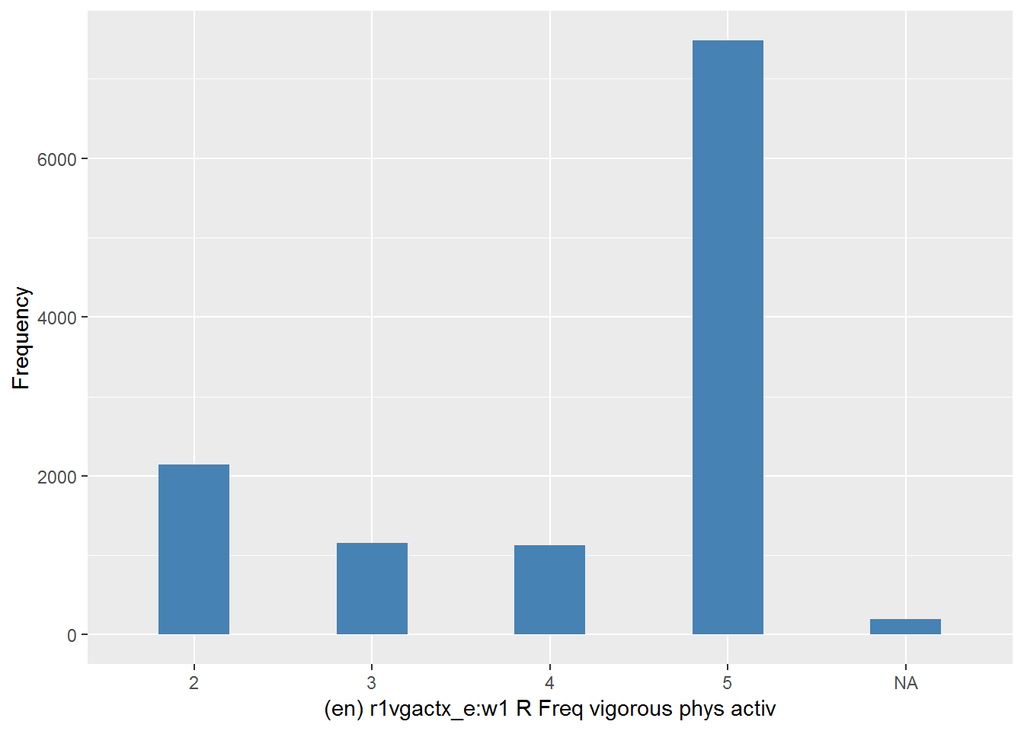

#### 2.1.1.2 Harmonisation algorithm

To compute `n_vig_pa` from the study-specific variable it has to be recoded as follows:

- `2 into 8`
- `3 into 2`
- `4 into 1`
- `5 into 0`
- `NA into 999`

**R script:**

```r
ELSA_ds_w1 <- tibble(id = ELSA_w1$id)
ELSA_ds_w1$n_vig_pa <- car::recode(ELSA_w1$r1vgactx_e, "2 = 8;3 = 2;4 = 1;5 = 0;NA = 999 ")
```

#### 2.1.1.3 Statistical description of the new harmonised variable

Number of times during past 2 weeks engaging in vigorous exercise

| Sample size | Missing values |
| --- | --- |
| 12099 | 194 |

Values

|  | No-missings | 991 | 992 | 993 | 994 | 995 | 996 | 997 | 998 | 999 | NA |
| --- | --- | --- | --- | --- | --- | --- | --- | --- | --- | --- | --- |
| Frequency | 11905.0 | 0 | 0 | 0 | 0 | 0 | 0 | 0 | 0 | 194.0 | 0 |
| Percentage | 98.4 | 0 | 0 | 0 | 0 | 0 | 0 | 0 | 0 | 1.6 | 0 |

Summary

| Min. | 1st Qu. | Median | Mean | 3rd Qu. | Max. |
| --- | --- | --- | --- | --- | --- |
| 0 | 0 | 0 | 1.73 | 2 | 8 |

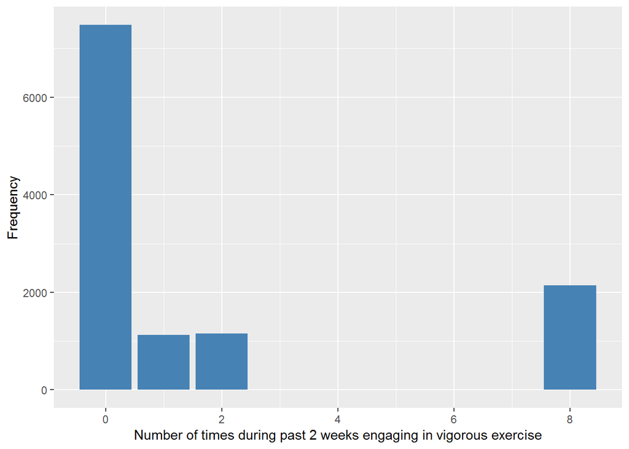

#### 2.1.1.4 Validation

### 2.1.2 Wave 2

#### 2.1.2.1 Study-specific variable description

| **Name** | `r2vgactx_e` |
| --- | --- |
| **Label** | `Frequency vigorous physical activities` |
| **Table name** | `h_elsa` |
| **Categories** | `2 = Respondent reported taking part in the given level of physical activity more than once a week` `3 = 1 per week` `4 = 1-3 per month` `5 = hardly ever or never` |
| **Missings** | `NA` |
| **Description** |  |

r2vgactx_e

| Sample size | Missing values |
| --- | --- |
| 9432 | 133 |

Category

|  | 2 | 3 | 4 | 5 |
| --- | --- | --- | --- | --- |
| Frequency | 1661.00 | 905.00 | 987.00 | 5746.00 |
| Percentage | 17.61 | 9.59 | 10.46 | 60.92 |

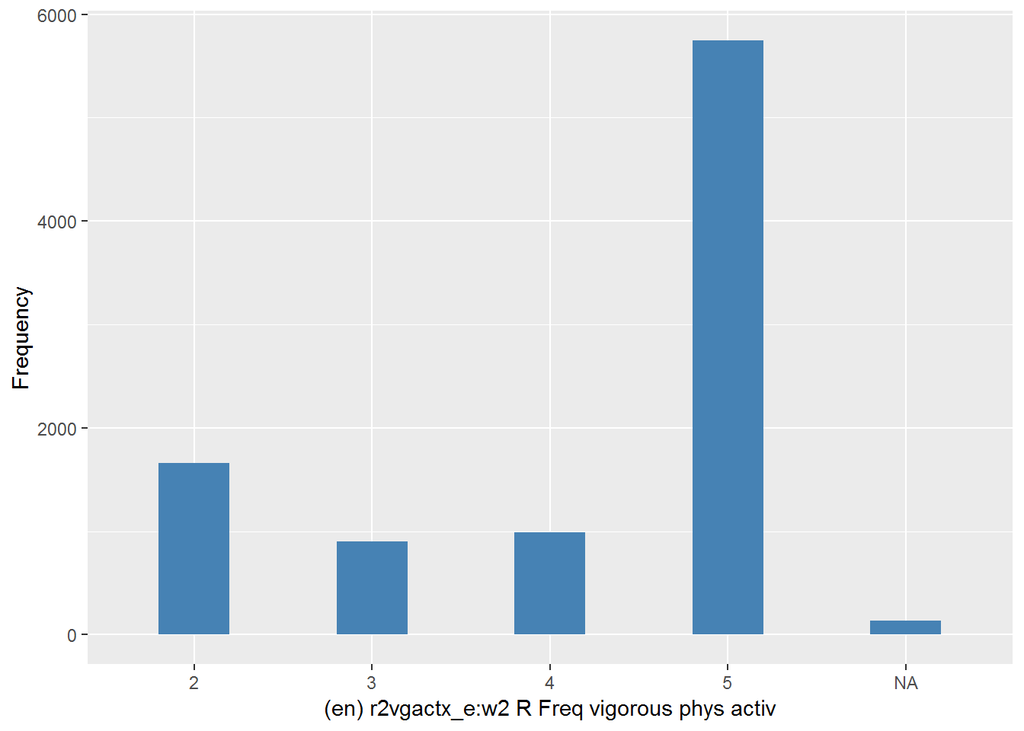

#### 2.1.2.2 Harmonisation algorithm

To compute `n_vig_pa` from the study-specific variable it has to be recoded as follows:

- `2 into 8`
- `3 into 2`
- `4 into 1`
- `5 into 0`
- `NA into 999`

**R script:**

```r
ELSA_ds_w2 <- tibble(id = ELSA_w2$id)
ELSA_ds_w2$n_vig_pa <- car::recode(ELSA_w2$r2vgactx_e, "2 = 8;3 = 2;4 = 1;5 = 0;NA = 999 ")
```

#### 2.1.2.3 Statistical description of the new harmonised variable

Number of times during past 2 weeks engaging in vigorous exercise

| Sample size | Missing values |
| --- | --- |
| 9432 | 133 |

Values

|  | No-missings | 991 | 992 | 993 | 994 | 995 | 996 | 997 | 998 | 999 | NA |
| --- | --- | --- | --- | --- | --- | --- | --- | --- | --- | --- | --- |
| Frequency | 9299.00 | 0 | 0 | 0 | 0 | 0 | 0 | 0 | 0 | 133.00 | 0 |
| Percentage | 98.59 | 0 | 0 | 0 | 0 | 0 | 0 | 0 | 0 | 1.41 | 0 |

Summary

| Min. | 1st Qu. | Median | Mean | 3rd Qu. | Max. |
| --- | --- | --- | --- | --- | --- |
| 0 | 0 | 0 | 1.73 | 2 | 8 |

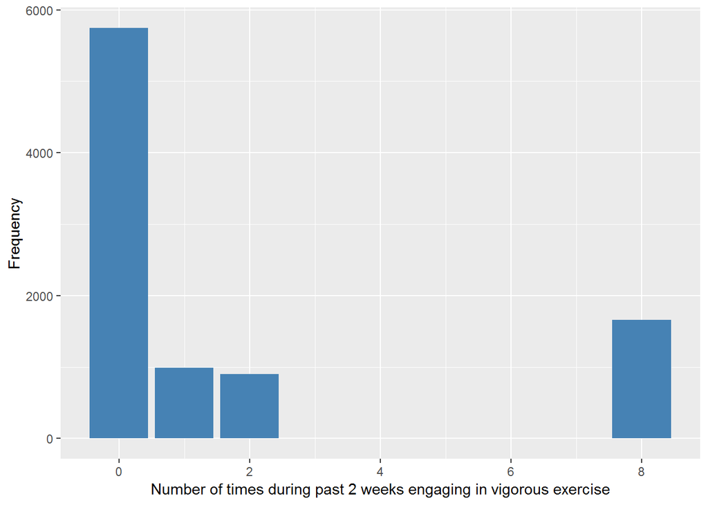

#### 2.1.2.4 Validation

### 2.1.3 Wave 3

#### 2.1.3.1 Study-specific variable description

| **Name** | `r3vgactx_e` |
| --- | --- |
| **Label** | `Frequency vigorous physical activities` |
| **Table name** | `h_elsa` |
| **Categories** | `2 = Respondent reported taking part in the given level of physical activity more than once a week` `3 = 1 per week` `4 = 1-3 per month` `5 = hardly ever or never` |
| **Missings** | `NA` |
| **Description** |  |

r3vgactx_e

| Sample size | Missing values |
| --- | --- |
| 9771 | 15 |

Category

|  | 2 | 3 | 4 | 5 |
| --- | --- | --- | --- | --- |
| Frequency | 1896.0 | 889.0 | 934.00 | 6037.00 |
| Percentage | 19.4 | 9.1 | 9.56 | 61.78 |

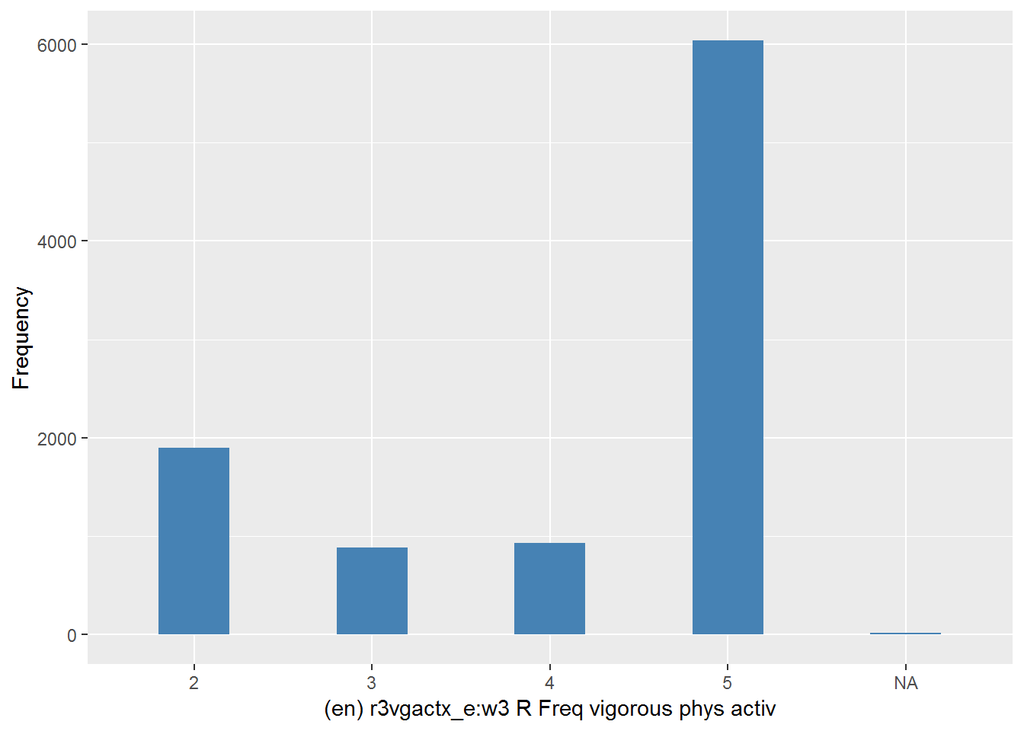

#### 2.1.3.2 Harmonisation algorithm

To compute `n_vig_pa` from the study-specific variable it has to be recoded as follows:

- `2 into 8`
- `3 into 2`
- `4 into 1`
- `5 into 0`
- `NA into 999`

**R script:**

```r
ELSA_ds_w3 <- tibble(id = ELSA_w3$id)
ELSA_ds_w3$n_vig_pa <- car::recode(ELSA_w3$r3vgactx_e, "2 = 8;3 = 2;4 = 1;5 = 0;NA = 999 ")
```

#### 2.1.3.3 Statistical description of the new harmonised variable

Number of times during past 2 weeks engaging in vigorous exercise

| Sample size | Missing values |
| --- | --- |
| 9771 | 15 |

Values

|  | No-missings | 991 | 992 | 993 | 994 | 995 | 996 | 997 | 998 | 999 | NA |
| --- | --- | --- | --- | --- | --- | --- | --- | --- | --- | --- | --- |
| Frequency | 9756.00 | 0 | 0 | 0 | 0 | 0 | 0 | 0 | 0 | 15.00 | 0 |
| Percentage | 99.85 | 0 | 0 | 0 | 0 | 0 | 0 | 0 | 0 | 0.15 | 0 |

Summary

| Min. | 1st Qu. | Median | Mean | 3rd Qu. | Max. |
| --- | --- | --- | --- | --- | --- |
| 0 | 0 | 0 | 1.833 | 2 | 8 |

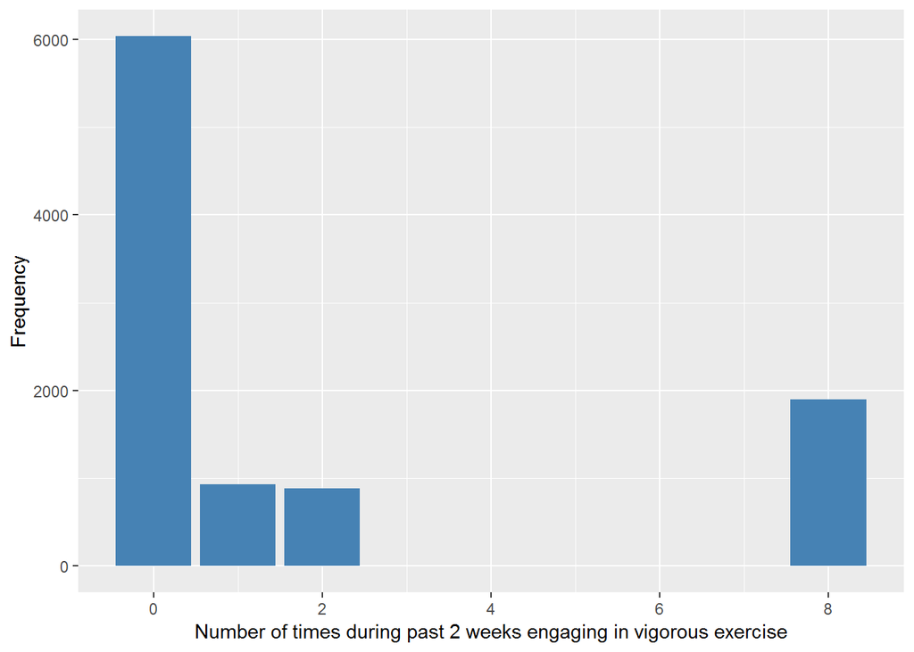

#### 2.1.3.4 Validation

### 2.1.4 Wave 4

#### 2.1.4.1 Study-specific variable description

| **Name** | `r4vgactx_e` |
| --- | --- |
| **Label** | `Frequency vigorous physical activities` |
| **Table name** | `h_elsa` |
| **Categories** | `2 = Respondent reported taking part in the given level of physical activity more than once a week` `3 = 1 per week` `4 = 1-3 per month` `5 = hardly ever or never` |
| **Missings** | `NA` |
| **Description** |  |

r4vgactx_e

| Sample size | Missing values |
| --- | --- |
| 11050 | 924 |

Category

|  | 2 | 3 | 4 | 5 |
| --- | --- | --- | --- | --- |
| Frequency | 1963.00 | 945.00 | 975.00 | 6243.0 |
| Percentage | 17.76 | 8.55 | 8.82 | 56.5 |

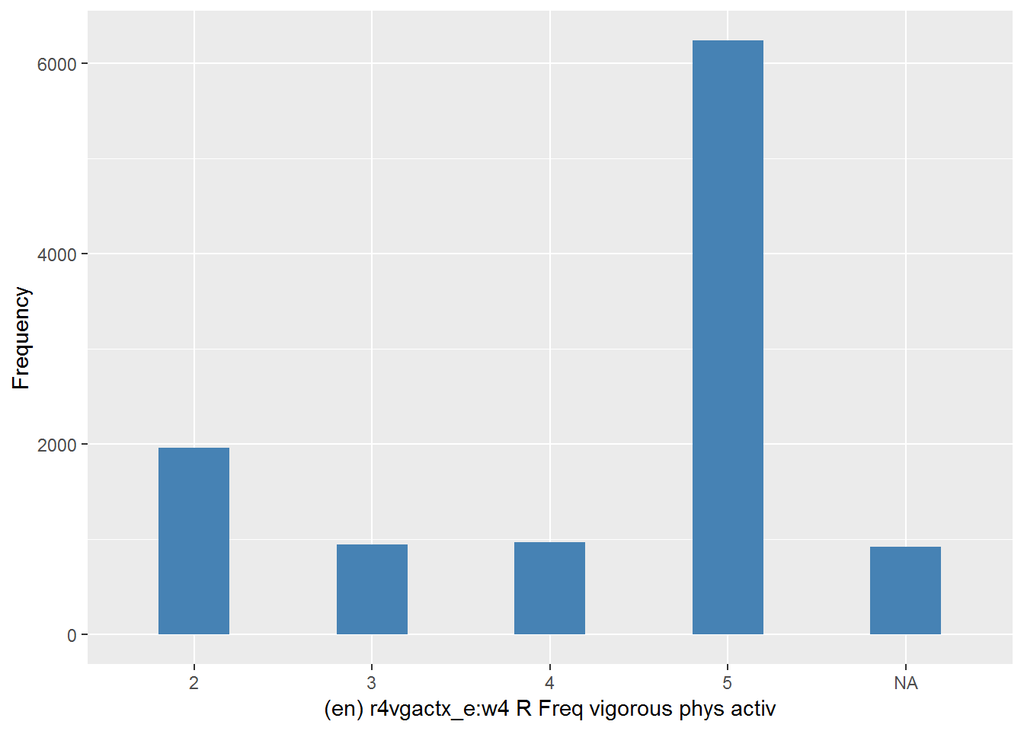

#### 2.1.4.2 Harmonisation algorithm

To compute `n_vig_pa` from the study-specific variable it has to be recoded as follows:

- `2 into 8`
- `3 into 2`
- `4 into 1`
- `5 into 0`
- `NA into 999`

**R script:**

```r
ELSA_ds_w4 <- tibble(id = ELSA_w4$id)
ELSA_ds_w4$n_vig_pa <- car::recode(ELSA_w4$r4vgactx_e, "2 = 8;3 = 2;4 = 1;5 = 0;NA = 999 ")
```

#### 2.1.4.3 Statistical description of the new harmonised variable

Number of times during past 2 weeks engaging in vigorous exercise

| Sample size | Missing values |
| --- | --- |
| 11050 | 924 |

Values

|  | No-missings | 991 | 992 | 993 | 994 | 995 | 996 | 997 | 998 | 999 | NA |
| --- | --- | --- | --- | --- | --- | --- | --- | --- | --- | --- | --- |
| Frequency | 10126.00 | 0 | 0 | 0 | 0 | 0 | 0 | 0 | 0 | 924.00 | 0 |
| Percentage | 91.64 | 0 | 0 | 0 | 0 | 0 | 0 | 0 | 0 | 8.36 | 0 |

Summary

| Min. | 1st Qu. | Median | Mean | 3rd Qu. | Max. |
| --- | --- | --- | --- | --- | --- |
| 0 | 0 | 0 | 1.834 | 2 | 8 |

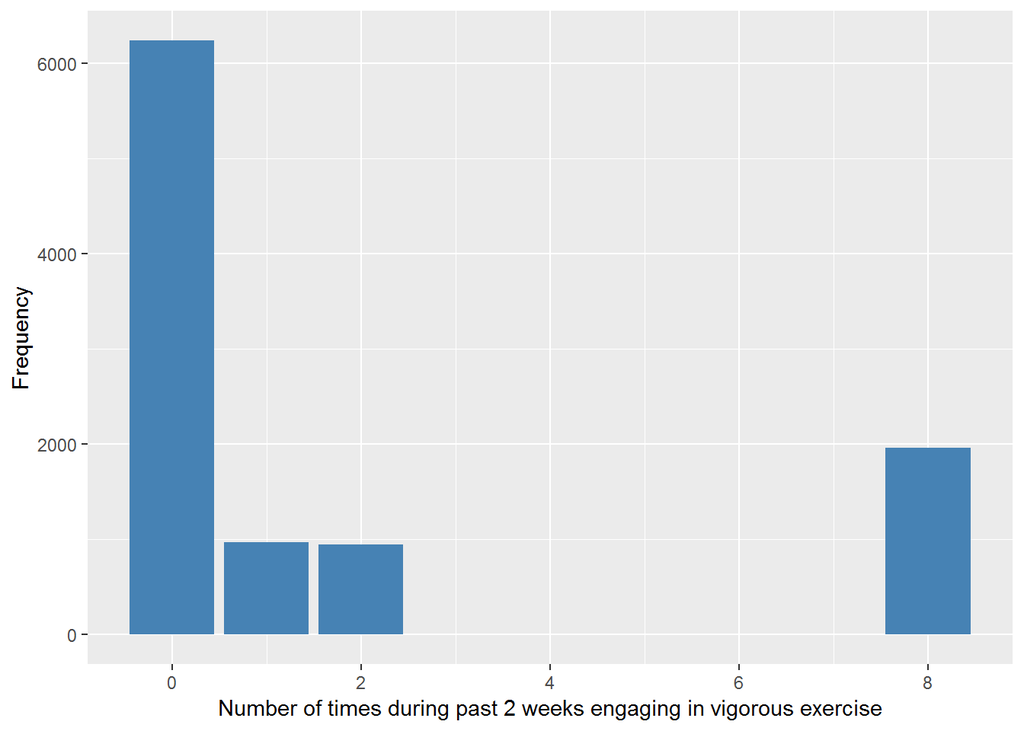

#### 2.1.4.4 Validation

### 2.1.5 Wave 5

#### 2.1.5.1 Study-specific variable description

| **Name** | `r5vgactx_e` |
| --- | --- |
| **Label** | `Frequency vigorous physical activities` |
| **Table name** | `h_elsa` |
| **Categories** | `2 = Respondent reported taking part in the given level of physical activity more than once a week` `3 = 1 per week` `4 = 1-3 per month` `5 = hardly ever or never` |
| **Missings** | `NA` |
| **Description** |  |

r5vgactx_e

| Sample size | Missing values |
| --- | --- |
| 10274 | 830 |

Category

|  | 2 | 3 | 4 | 5 |
| --- | --- | --- | --- | --- |
| Frequency | 1766.00 | 890.00 | 957.00 | 5831.00 |
| Percentage | 17.19 | 8.66 | 9.31 | 56.75 |

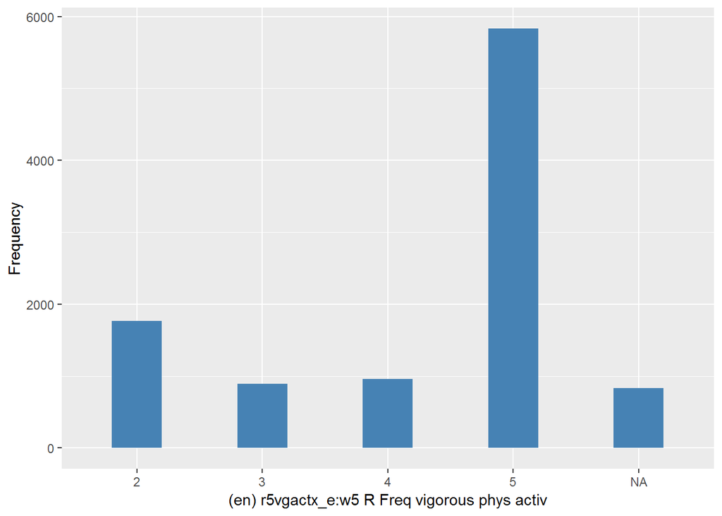

#### 2.1.5.2 Harmonisation algorithm

To compute `n_vig_pa` from the study-specific variable it has to be recoded as follows:

- `2 into 8`
- `3 into 2`
- `4 into 1`
- `5 into 0`
- `NA into 999`

**R script:**

```r
ELSA_ds_w5 <- tibble(id = ELSA_w5$id)
ELSA_ds_w5$n_vig_pa <- car::recode(ELSA_w5$r5vgactx_e, "2 = 8;3 = 2;4 = 1;5 = 0;NA = 999 ")
```

#### 2.1.5.3 Statistical description of the new harmonised variable

Number of times during past 2 weeks engaging in vigorous exercise

| Sample size | Missing values |
| --- | --- |
| 10274 | 830 |

Values

|  | No-missings | 991 | 992 | 993 | 994 | 995 | 996 | 997 | 998 | 999 | NA |
| --- | --- | --- | --- | --- | --- | --- | --- | --- | --- | --- | --- |
| Frequency | 9444.00 | 0 | 0 | 0 | 0 | 0 | 0 | 0 | 0 | 830.00 | 0 |
| Percentage | 91.92 | 0 | 0 | 0 | 0 | 0 | 0 | 0 | 0 | 8.08 | 0 |

Summary

| Min. | 1st Qu. | Median | Mean | 3rd Qu. | Max. |
| --- | --- | --- | --- | --- | --- |
| 0 | 0 | 0 | 1.786 | 2 | 8 |

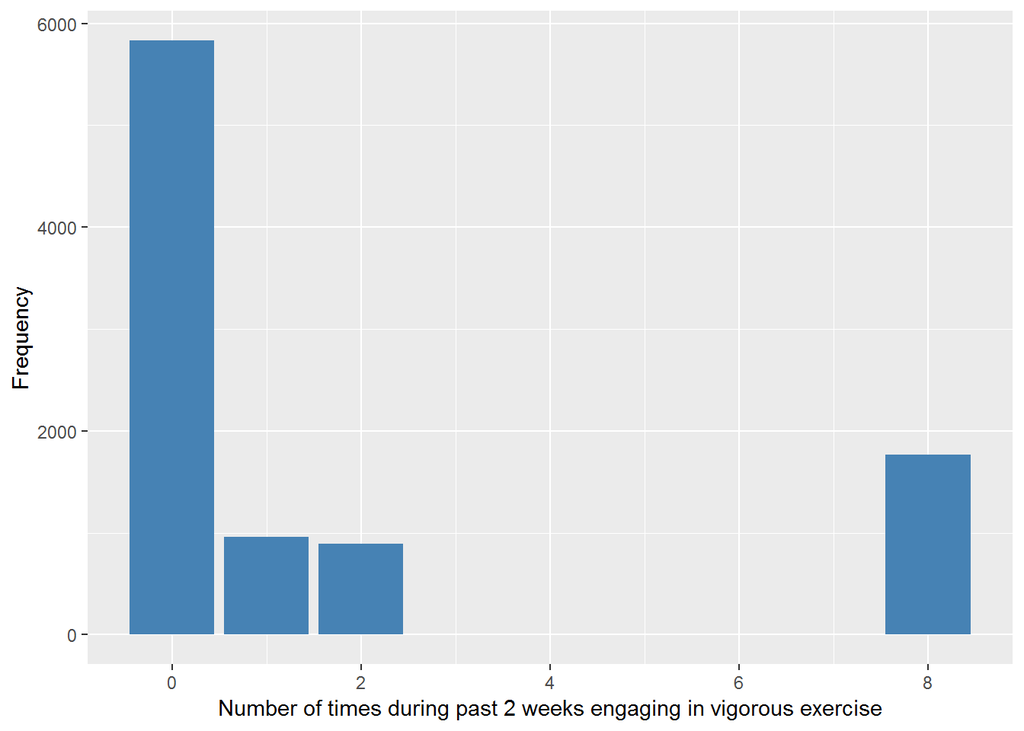

#### 2.1.5.4 Validation

### 2.1.6 Wave 6

#### 2.1.6.1 Study-specific variable description

| **Name** | `r6vgactx_e` |
| --- | --- |
| **Label** | `Frequency vigorous physical activities` |
| **Table name** | `h_elsa` |
| **Categories** | `2 = Respondent reported taking part in the given level of physical activity more than once a week` `3 = 1 per week` `4 = 1-3 per month` `5 = hardly ever or never` |
| **Missings** | `NA` |
| **Description** |  |

r6vgactx_e

| Sample size | Missing values |
| --- | --- |
| 10601 | 1960 |

Category

|  | 2 | 3 | 4 | 5 |
| --- | --- | --- | --- | --- |
| Frequency | 1662.00 | 793.00 | 781.00 | 5405.00 |
| Percentage | 15.68 | 7.48 | 7.37 | 50.99 |

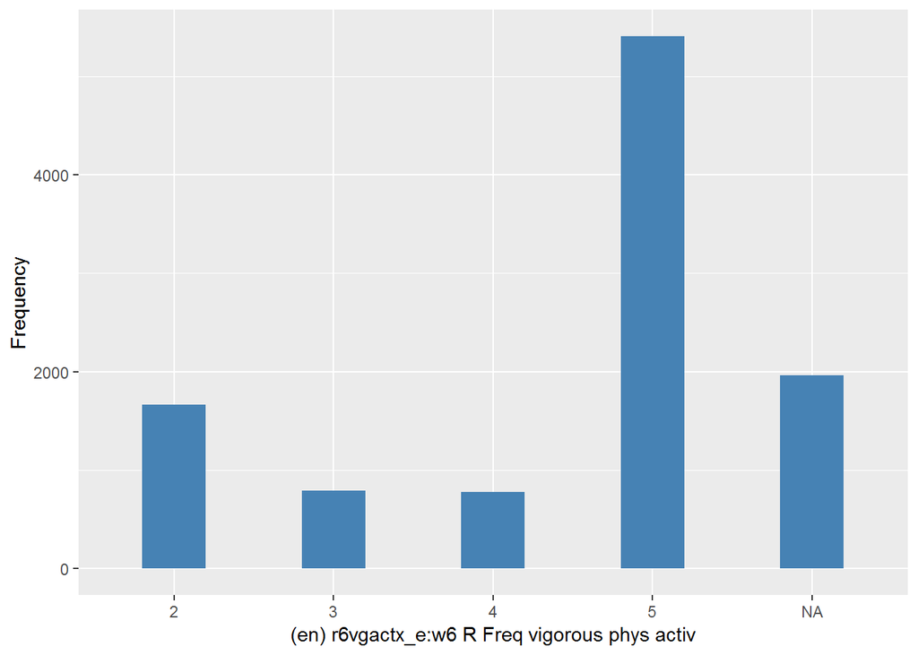

#### 2.1.6.2 Harmonisation algorithm

To compute `n_vig_pa` from the study-specific variable it has to be recoded as follows:

- `2 into 8`
- `3 into 2`
- `4 into 1`
- `5 into 0`
- `NA into 999`

**R script:**

```r
ELSA_ds_w6 <- tibble(id = ELSA_w6$id)
ELSA_ds_w6$n_vig_pa <- car::recode(ELSA_w6$r6vgactx_e, "2 = 8;3 = 2;4 = 1;5 = 0;NA = 999 ")
```

#### 2.1.6.3 Statistical description of the new harmonised variable

Number of times during past 2 weeks engaging in vigorous exercise

| Sample size | Missing values |
| --- | --- |
| 10601 | 1960 |

Values

|  | No-missings | 991 | 992 | 993 | 994 | 995 | 996 | 997 | 998 | 999 | NA |
| --- | --- | --- | --- | --- | --- | --- | --- | --- | --- | --- | --- |
| Frequency | 8641.00 | 0 | 0 | 0 | 0 | 0 | 0 | 0 | 0 | 1960.00 | 0 |
| Percentage | 81.51 | 0 | 0 | 0 | 0 | 0 | 0 | 0 | 0 | 18.49 | 0 |

Summary

| Min. | 1st Qu. | Median | Mean | 3rd Qu. | Max. |
| --- | --- | --- | --- | --- | --- |
| 0 | 0 | 0 | 1.813 | 2 | 8 |

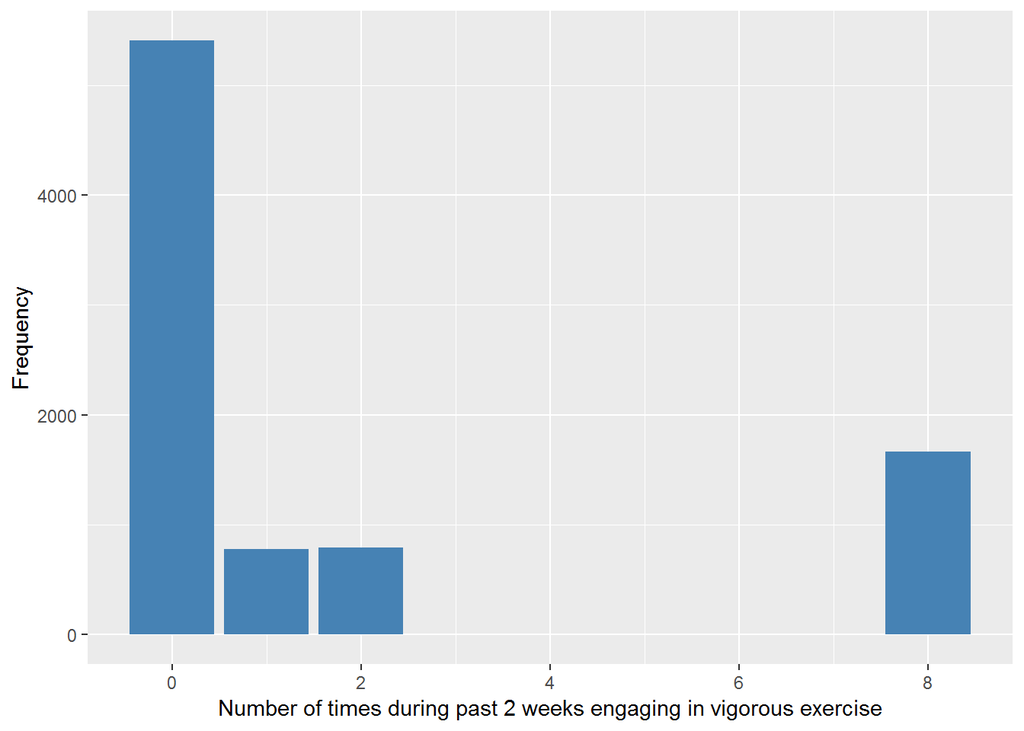

#### 2.1.6.4 Validation

### 2.1.7 Wave 7

Not found.

## 2.2 Summary of descriptive statistics of the harmonised variable accross populations and waves

Number of times during past 2 weeks engaging in vigorous exercise

| n_vig_pa | W1 | W2 | W3 | W4 | W5 | W6 |
| --- | --- | --- | --- | --- | --- | --- |
| Min. | 0 | 0 | 0 | 0 | 0 | 0 |
| 1st Qu. | 0 | 0 | 0 | 0 | 0 | 0 |
| Median | 0 | 0 | 0 | 0 | 0 | 0 |
| Mean | 1.73 | 1.73 | 1.833 | 1.834 | 1.786 | 1.813 |
| 3rd Qu. | 2 | 2 | 2 | 2 | 2 | 2 |
| Max. | 8 | 8 | 8 | 8 | 8 | 8 |
| No-missings | 11905 | 9299 | 9756 | 10126 | 9444 | 8641 |
| 991 | 0 | 0 | 0 | 0 | 0 | 0 |
| 992 | 0 | 0 | 0 | 0 | 0 | 0 |
| 993 | 0 | 0 | 0 | 0 | 0 | 0 |
| 994 | 0 | 0 | 0 | 0 | 0 | 0 |
| 995 | 0 | 0 | 0 | 0 | 0 | 0 |
| 996 | 0 | 0 | 0 | 0 | 0 | 0 |
| 997 | 0 | 0 | 0 | 0 | 0 | 0 |
| 998 | 0 | 0 | 0 | 0 | 0 | 0 |
| 999 | 194 | 133 | 15 | 924 | 830 | 1960 |
| NA | 0 | 0 | 0 | 0 | 0 | 0 |
| sample size | 12099 | 9432 | 9771 | 11050 | 10274 | 10601 |

# 3 Quality estimation

[Comments on the quality of the new harmonised variable.]